# Group Lasso with `grpreg` Package

This is an [R Markdown](http://rmarkdown.rstudio.com) Notebook demonstrating the implementation of the **group lasso** using the `grpreg` package. The group lasso is a regularization method for regression with grouped predictors, where sparsity is encouraged at the group level.

## **1. Install and Load the `grpreg` Package**

First, we install and load the `grpreg` package, which provides functions for fitting group lasso models.

```r
# Install the grpreg package if not already installed
if (!require('grpreg')) {
  install.packages('grpreg')
}
# Load the grpreg package
library(grpreg)
```

## **2. Simulate Data**

We simulate a dataset with grouped predictors. The response variable `y` is generated as a linear combination of the predictors `X` with some added noise.

```r
# Set seed for reproducibility
set.seed(123)

# Number of observations
n <- 100

# Number of predictors
p <- 10

# Predictor matrix (random normal data)
X <- matrix(rnorm(n * p), n, p)

# Group structure (5 groups of size 2 each)
groups <- c(1, 1, 2, 2, 3, 3, 4, 4, 5, 5)

# True coefficients (only groups 1 and 3 are active)
beta <- c(2, 2, 0, 0, 1, 1, 0, 0, 0, 0)

# Response variable (linear combination of predictors + noise)
y <- X %*% beta + rnorm(n)
```

## **3. Fit the Group Lasso Model**

We fit the group lasso model using the `grpreg` function. The `group` argument specifies the group structure, and the `penalty` argument specifies the group lasso penalty.

```r
# Fit the group lasso model
fit <- grpreg(X, y, group = groups, penalty = "grLasso")

# Display a summary of the model
summary(fit)
```

```
                  Length Class  Mode
beta               1100  -none- numeric
family                1  -none- character
group                10  factor numeric
lambda              100  -none- numeric
alpha                 1  -none- numeric
deviance            100  -none- numeric
linear.predictors 10000  -none- numeric
n                     1  -none- numeric
penalty               1  -none- character
df                  100  -none- numeric
iter                100  -none- numeric
group.multiplier      5  table  numeric
y                   100  -none- numeric
```

## **4. Visualize the Solution Path**

The solution path shows how the coefficients change as the regularization parameter $\lambda$ varies. Groups are either included or excluded as $\lambda$ decreases.

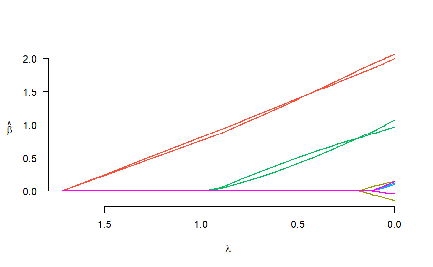

```r
# Plot the solution path
plot(fit)
```

## **5. Perform Cross-Validation**

We use cross-validation to select the optimal value of the regularization parameter $\lambda$. The `cv.grpreg` function performs cross-validation and returns the optimal $\lambda$.

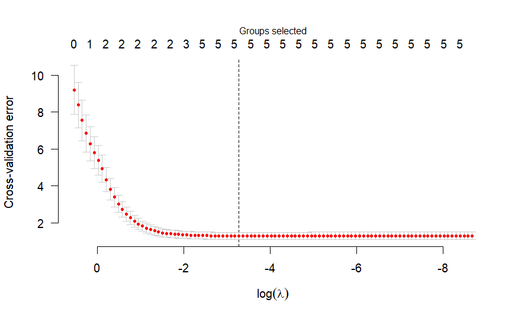

```r
# Perform cross-validation
cvfit <- cv.grpreg(X, y, group = groups, penalty = "grLasso")

# Plot the cross-validation results
plot(cvfit)
```

## **6. Extract the Optimal Model**

The optimal $\lambda$ value and the corresponding coefficients are extracted from the cross-validation results.

```r
# Optimal lambda value
lambda_min <- cvfit$lambda.min
cat("Optimal lambda:", lambda_min, "\n")
```

```
Optimal lambda: 0.03791532
```

```r
# Coefficients at the optimal lambda
optimal_coef <- coef(cvfit)
print(optimal_coef)
```

```
(Intercept)          V1          V2          V3          V4          V5          V6          V7          V8          V9
 0.13291218  2.01690061  1.94832363 -0.11749838  0.11362505  1.01267023  0.93138791  0.05920091  0.07731250 -0.03873350
        V10
 0.09021807
```

## **7. Interpretation of Results**

- **Solution Path:** The plot shows how the coefficients change with $\lambda$. Groups are either included or excluded as $\lambda$ varies.
- **Cross-Validation:** The plot of cross-validation results helps identify the optimal $\lambda$ that minimizes prediction error.
- **Optimal Model:** The coefficients at the optimal $\lambda$ indicate which groups are selected as important predictors.

## **8. Save the Results (Optional)**

The results (e.g., coefficients, optimal lambda) to a file for future reference.

```r
# Assign column names to the predictor matrix X
colnames(X) <- paste0("X", 1:p)  # Assign names like X1, X2, ..., X10

# Save the results to a CSV file
write.csv(data.frame(
  Predictor = colnames(X),  # Use the assigned column names
  Coefficient = optimal_coef[-1],  # Exclude intercept
  Lambda = lambda_min,
  Group = groups
), file = "group_lasso_results.csv", row.names = FALSE)
```

## **References**

- Breiman, L. (1995). Better subset regression using the nonnegative garrote. *Technometrics*, 37(4), 373–384.
- Yuan, M., & Lin, Y. (2006). Model selection and estimation in regression with grouped variables. *Journal of the Royal Statistical Society: Series B*, 68(1), 49–67. ```